# PS6

Nicole Higgins

2/24/2021

## 6.1

**e.**

```r
x0 = c(1,0)
A = cbind(c(1/2,1/2),
          c(1/10,9/10))

for (i in 1:2000) {
  x0 = A %*% x0
}
x0
```

```
##           [,1]
## [1,] 0.1666667
## [2,] 0.8333333
```

this vector is in the space of A infinite found previously, as expected.

## 6.4

```r
A = cbind(c(57/50,4/50),c(-6/50,43/50))
eigen(A)
```

```
## eigen() decomposition
## $values
## [1] 1.1 0.9
##
## $vectors
##           [,1]      [,2]
## [1,] 0.9486833 0.4472136
## [2,] 0.3162278 0.8944272
```

**a.**

```r
p = cbind(c(3,1),
          c(1,2))
d = cbind(c(1.1,0),
          c(0,.9))
x = c(10,15)

p%*%(d**10)%*%solve(p)%*%x
```

```
##           [,1]
## [1,] 10.221976
## [2,]  7.475241
```

**b.**

```r
solve(p)%*%x
```

```
##      [,1]
## [1,]    1
## [2,]    7
```

thus  
rt = 3 * (1.1<sup>t</sup>) + 7 * (0.9<sup>t</sup>) and  
ct = 1 * (1.1<sup>t</sup>) + 14 * (0.9<sup>t</sup>)  
long term, the second term in each projection will go to 0 (eigenvalue .9) so we are left with the ratio—  
rt:ct = 3(1.1<sup>t</sup>):(1.1<sup>t</sup>) = 3:1  
**c.**  
their starting population, <5,10>, is in the eigenvector of eigenvalue .9, <1,2>,  
and the long run of being on that line is 0 since the eigenvalue is less than 1.

## 6.5

**a.**

```r
A = cbind(c(-8, 3, 29), c(-40, 24, 46), c(10, 3, 11))
B = cbind(c(4, 3, 35), c(-49, 42, 55), c(13, 3, 26))
eigen(A)$vectors
```

```
##            [,1]       [,2]          [,3]
## [1,] -0.3244428  0.8451543 -7.071068e-01
## [2,]  0.4866643 -0.5070926 -6.839954e-17
## [3,]  0.8111071  0.1690309  7.071068e-01
```

```r
eigen(B)$vectors
```

```
##            [,1]       [,2]          [,3]
## [1,]  0.3244428 -0.8451543  7.071068e-01
## [2,] -0.4866643  0.5070926  6.034093e-17
## [3,] -0.8111071 -0.1690309 -7.071068e-01
```

```r
eigen(A)$values
```

```
## [1]  27  18 -18
```

```r
eigen(B)$values
```

```
## [1] 45 36 -9
```

**b.**

```r
A%*%B
```

```
##      [,1] [,2] [,3]
## [1,]  198 -738   36
## [2,]  189 1026  189
## [3,]  639 1116  801
```

```r
B%*%A
```

```
##      [,1] [,2] [,3]
## [1,]  198 -738   36
## [2,]  189 1026  189
## [3,]  639 1116  801
```

**c.** on the pdf

## 6.6

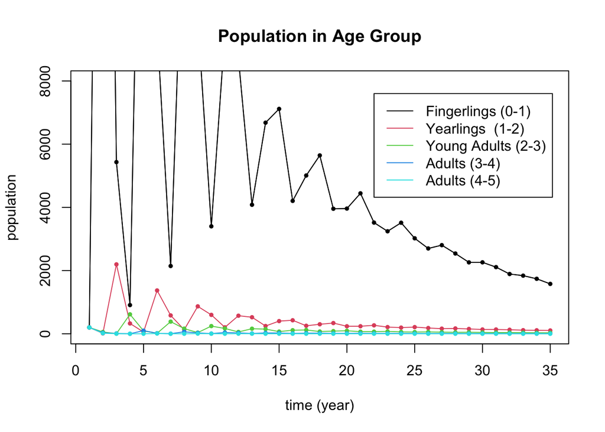

**a.**  
37, 64, and 82 are scalars on the current population of young adults, adults<sub>1</sub> and adults<sub>2</sub>,  
respectively, that sum to equal the projected population of fingerlings a year from now.  
Aka, the reproductive rate of each adult age group. 0.06, 0.28, 0.16, 0.08 are scalars on the amount of  
fingerlings, yearlings, young adults, and adults, respectively, that are expected to make it to the next year of life.

**b.**

```r
eigen(L)
```

```
## eigen() decomposition
## $values
## [1]  0.9379134+0.0000000i -0.3307275+0.7478777i -0.3307275-0.7478777i
## [4] -0.1382292+0.0949088i -0.1382292-0.0949088i
##
## $vectors
##                 [,1]                        [,2]                        [,3]
## [1,] 0.9977735535+0i  9.969940e-01+0.000000e+00i  9.969940e-01+0.000000e+00i
## [2,] 0.0638293640+0i -2.958569e-02-6.690244e-02i -2.958569e-02+6.690244e-02i
## [3,] 0.0190553016+0i -1.685357e-02+1.852968e-02i -1.685357e-02-1.852968e-02i
## [4,] 0.0032506715+0i  4.649456e-03+1.549543e-03i  4.649456e-03-1.549543e-03i
## [5,] 0.0002772684+0i -4.532180e-05-4.773071e-04i -4.532180e-05+4.773071e-04i
##                       [,4]                  [,5]
## [1,]  0.7285045+0.0000000i  0.7285045+0.0000000i
## [2,] -0.2149044-0.1475544i -0.2149044+0.1475544i
## [3,]  0.1563764+0.4062580i  0.1563764-0.4062580i
## [4,]  0.0964136-0.4040447i  0.0964136+0.4040447i
## [5,] -0.1470378+0.1328836i -0.1470378-0.1328836i
```

The overall population growth rate is the dominant eigenvalue: 0.9379134 The limiting age distribution is the eigenvector relating to such eigenvalue, unitized:

```r
length = sum(eigen(L)$vectors[,1])
eigen(L)$vectors[,1]/length
```

```
## [1] 0.9202972618+0i 0.0588730667+0i 0.0175756732+0i 0.0029982596+0i
## [5] 0.0002557387+0i
```

**c.**

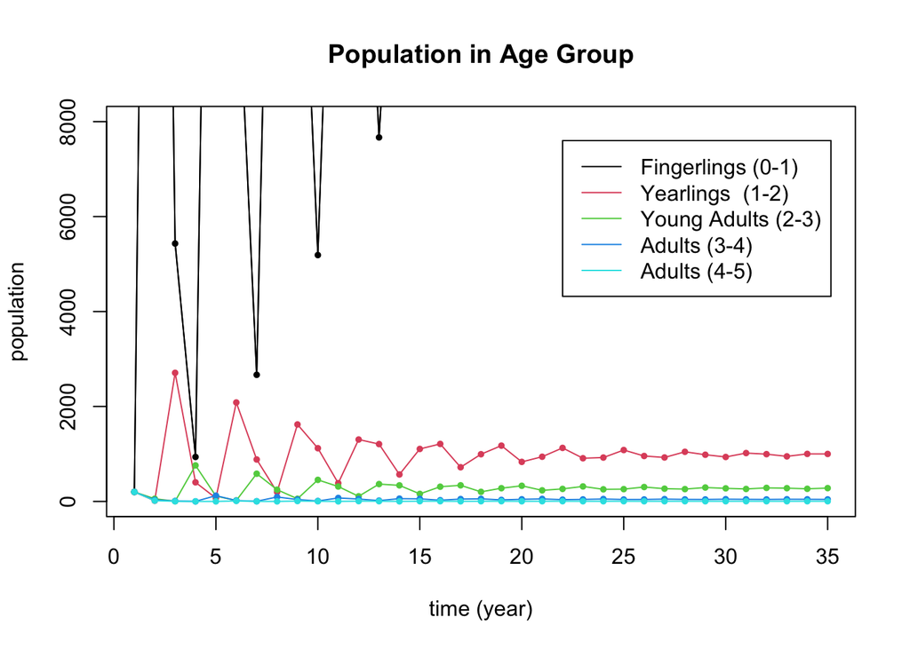

```r
C = cbind(c(0,.074,0,0,0),
          c(0,0,.28,0,0),
          c(37,0,0,.16,0),
          c(64,0,0,0,.08),
          c(82,0,0,0,0.00))

start = c(200,200,200,200,200)  # the starting distribution
N = 35              # N is the number of iterations
X = matrix(0,nrow=5,ncol=N)  #  Store the results in a 3 x N matrix called X
X[,1] = start  # put start in the first column of X
# loop N times and put your results in X
for (i in 2:N) {X[,i] = C %*% X[,i-1]}
# Then plot the results
t = seq(1,N)  # time
plot(t,X[1,],type='l',col=1,ylim=c(0,8000),ylab="population",xlab="time (year)",
     main="Population in Age Group")
for (i in 1:5) {
  lines(t,X[i,],col=i)
  points(t,X[i,],col=i,pch=20,cex=.8)}
legend(22, 7600, legend=c("Fingerlings (0-1)", "Yearlings  (1-2)", "Young Adults (2-3)","Adults (3-4)","Adults (4-5)"), col=1:5, lty=1)
```

```r
eigen(C)$values
```

```
## [1]  1.0001721+0.0000000i -0.3618248+0.8007239i -0.3618248-0.8007239i
## [4] -0.1382613+0.0951148i -0.1382613-0.0951148i
```

By improving the survival rate by just 1.4% (from 6% to 7.4%) we can save the Brook Trout.  
This boost in survival rate bumps the dominant eigenvector to 1.0001721, which will cause population growth as it is >1

## 6.7

**a.**

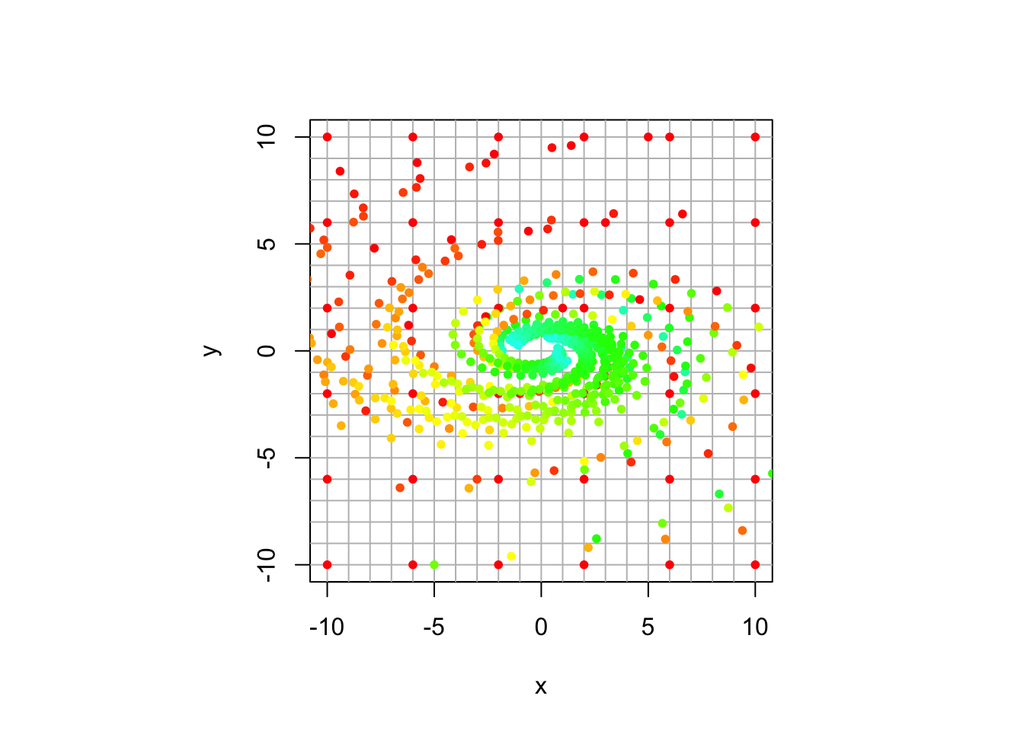

```r
A = cbind(c(.9,.1),c(-0.4,0.9))
trajectory_plot(A, t=10, datamax=10, plotmax=10, numpoints=5)
```

**b.**

```r
eigen(A)
```

```
## eigen() decomposition
## $values
## [1] 0.9+0.2i 0.9-0.2i
##
## $vectors
##                      [,1]                 [,2]
## [1,] 0.8944272+0.0000000i 0.8944272+0.0000000i
## [2,] 0.0000000-0.4472136i 0.0000000+0.4472136i
```

**c.**  
λ = 0.9 ± 0.2i  
v = <0.8944272,0> ± <0,0.4472136>i

**d.**

```r
(dil = sqrt(.9^2 + 0.2^2))
```

```
## [1] 0.9219544
```

```r
(rot = atan(.2/.9)/(2*pi)*360)
```

```
## [1] 12.52881
```

**e.**  
The dilation factor shows us that the plot spirals towards zero over time because it is less than one. The plot appears to be rotating at roughly 12.5 degrees.